# pySummarizedExperiment

In the various -omics fields measurements are often done on assay of genes x samples or compounds x aliquots (here, I will generalize by using features x samples). However, data is often stored in a ‘long’ dataframe format where each combination of feature - sample - measurement gets a single row. This is not an issue on a small scale, but as I will demonstrate, this becomes problematic on large-scale experiments. Before I dive into pySummarizedExperiment, Python version of R’s SummarizedExperiment package, I will discuss the long dataframe format first. An example is shown below.

| Compound | Sample | Value |
| --- | --- | --- |
| 1 | A | 314.0590 |
| 2 | A | 540.8519 |
| 3 | A | 133.3960 |
| 1 | B | 892.9832 |
| 2 | B | 603.2795 |
| 3 | B | 675.1796 |
| 1 | C | 118.8818 |
| 2 | C | 330.1472 |
| 3 | C | 329.3114 |

This format has a couple of advantages. For example, it is easy to store complex data in a single file, while simultaneous being human-readable. However, it is not efficient as it will cause data duplication. With increasing data sizes due to improved measurements and the rising field of single-cell omics, the data duplication effect is quickly becoming more important.

In a long dataframe, the amount of rows needed can be calculated by multiplying the number of features x number of samples. For most -omics studies, there are about 2.000 - 20.000 features with an increasing amount of samples (often represented by patients). With 100 patients, the number of rows needed is between 200.000 and 2 million. However, with single cell omics on the rise, the number of samples can exceed over 100.000. This would result in 200 million - 2 billion rows of data, an enormous amount.

This is not the full story. For each feature, we often have metadata we use to subset our data or that is used in algorithms. For example, for each feature we might want to store identifiers for databases, properties like the sequence (in case of transcripts) or molecular mass (in case of proteomics / metabolomics). For samples we might want to attach attributes like date of measurement, sample type, phenotype, and/or other identifiers. In a long dataframe, each of these attributes will have its own column, with features x samples datapoints. As I will demonstrate, not only are these metadata the cause of major memory usage, the number of metadata columns is actually the fold change limit when comparing data storage between a long dataframe and a pySummarizedExperiment.

There is another reason why the long format is not desired, in particular for data analysis. Most statistical algorithms depend in some way on a matrix format of rows x columns. The best example is a Principle Component Analysis (PCA), which requires you to format the data in matrices. It is not uncommon to encounter code that transforms dataframes into matrices just to perform a PCA. Lastly, while a long dataframe stores all data in a single representation, it consequently combines data and metadata. This requires you to subset your dataframe to obtain only data before applying algorithms.

Clearly there are several disadvantages of combining data into a single dataframe, that become increasingly apparent with bigger studies.

## The pySummarizedExperiment object

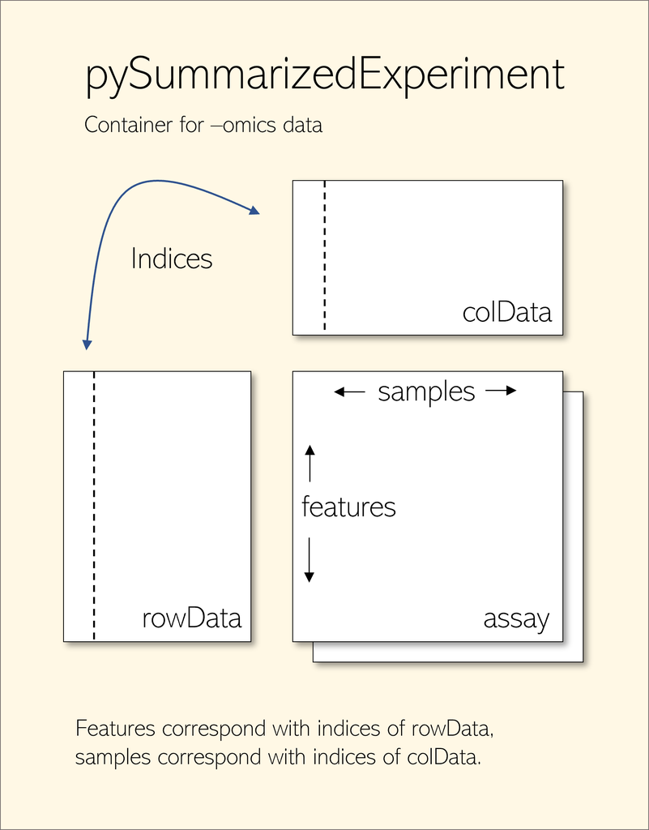

The pySummarizedExperiment object circumvents these issues by restructuring data with constraints. These prevent the occurrence of many-to-many relationships between columns. Simultaneously, this separates metadata from actual data, making it possible to apply algorithms without sub setting.

The core message of this post is to separate your metadata from your data whenever possible. To still have all (meta)data available in a single object, pySummarizedExperiment was developed.